# Budweiser Presentation

## Introduction

Good morning.  
Today we will showcase the answers to the following questions based on the provided data:  
* Where are breweries located in the United States?  
* Where did we land post data clean up?  
* What is the median ABV and IBU in each state?  
* Who has the most alcoholic and most bitter beer?  
* What does the ABV distribution look like in the United States?  
* Is there a relationship between ABV and IBU?  
We will also look into our ability to successfully identify an IPA.  
Finally, we will showcase promising test markets for a new IPA.

## Where are breweries located in the United States?

The graphic below provides a heat map of the breweries in all 50 states and Washington DC.

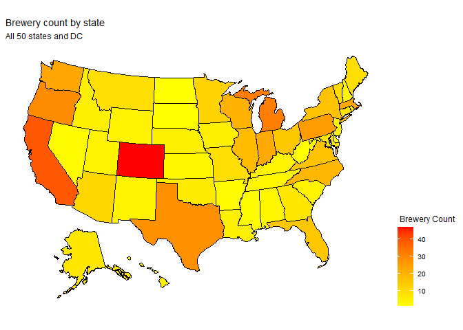

```r
#load brewery data
breweries <- read.csv(curl("https://raw.githubusercontent.com/tricleve/6306_CaseStudy1/master/Breweries.csv"))
#Trim space in front of abbreviation
breweries$abbr = str_trim(breweries$State)
#Rename Brewery id column to enable merge with beers.csv
colnames(breweries)[1] = "Brewery_id"
#Generate brewery count by state
brewery_count_by_state = count(breweries,abbr)
#Clean up column name to be more descriptive
colnames(brewery_count_by_state)[2] = "Breweries"
#Merge/select brewery count with statepop (usmap data set) to get fips for plot.
plotbrew = merge(statepop,brewery_count_by_state,by = "abbr") %>% select(fips, Breweries)
#Plot brewery count on the state map.  Includes Alaska, Hawaii and DC
plot_usmap(data=plotbrew, values="Breweries", color = "black") + scale_fill_gradient(name = " Brewery Count", low = "yellow", high = "red") + labs(title="Brewery count by state", subtitle="All 50 states and DC") + theme(legend.position = "right")
```

The code above cleans the brewery data, merges the brewery data with the “statepop” data set from the usmap library and finally plots the brewery counts by state as a heat map using the plot_usmap function.

## Merging beer data with brewery data

```r
beers <- read.csv(curl("https://raw.githubusercontent.com/tricleve/6306_CaseStudy1/master/Beers.csv"))
#Full join to ensure we bring in all data from both sets
comb_data = full_join(beers,breweries, by="Brewery_id")
tail(comb_data, 6)
```

```
##                           Name.x Beer_ID   ABV IBU Brewery_id
## 2405 Rocky Mountain Oyster Stout    1035 0.075  NA        425
## 2406                   Belgorado     928 0.067  45        425
## 2407               Rail Yard Ale     807 0.052  NA        425
## 2408             B3K Black Lager     620 0.055  NA        425
## 2409         Silverback Pale Ale     145 0.055  40        425
## 2410        Rail Yard Ale (2009)      84 0.052  NA        425
##                         Style Ounces                  Name.y   City State abbr
## 2405           American Stout     12 Wynkoop Brewing Company Denver    CO   CO
## 2406              Belgian IPA     12 Wynkoop Brewing Company Denver    CO   CO
## 2407 American Amber / Red Ale     12 Wynkoop Brewing Company Denver    CO   CO
## 2408              Schwarzbier     12 Wynkoop Brewing Company Denver    CO   CO
## 2409  American Pale Ale (APA)     12 Wynkoop Brewing Company Denver    CO   CO
## 2410 American Amber / Red Ale     12 Wynkoop Brewing Company Denver    CO   CO
```

```r
head(comb_data, 6)
```

```
##                Name.x Beer_ID   ABV IBU Brewery_id
## 1            Pub Beer    1436 0.050  NA        409
## 2         Devil's Cup    2265 0.066  NA        178
## 3 Rise of the Phoenix    2264 0.071  NA        178
## 4            Sinister    2263 0.090  NA        178
## 5       Sex and Candy    2262 0.075  NA        178
## 6        Black Exodus    2261 0.077  NA        178
##                            Style Ounces                    Name.y City State
## 1            American Pale Lager     12 10 Barrel Brewing Company Bend    OR
## 2        American Pale Ale (APA)     12       18th Street Brewery Gary    IN
## 3                   American IPA     12       18th Street Brewery Gary    IN
## 4 American Double / Imperial IPA     12       18th Street Brewery Gary    IN
## 5                   American IPA     12       18th Street Brewery Gary    IN
## 6                  Oatmeal Stout     12       18th Street Brewery Gary    IN
##   abbr
## 1   OR
## 2   IN
## 3   IN
## 4   IN
## 5   IN
## 6   IN
```

The code above reads the beers.csv from github and completes a full join of beers.csv and breweries.csv.

## Where did we land post data clean up?

```r
sum(is.na(comb_data$ABV))
```

```
## [1] 62
```

```r
sum(is.na(comb_data$IBU))
```

```
## [1] 1005
```

```r
sum(is.na(comb_data$Style))
```

```
## [1] 0
```

```r
beerclean = comb_data %>% filter (!is.na(ABV) & !is.na(IBU) & !is.na(Style))
dim(comb_data)
```

```
## [1] 2410   11
```

```r
dim(beerclean)
```

```
## [1] 1405   11
```

The code above identifies the missing values in three fields(ABV, IBU and Style) and then removes them from the combined data set.

## What is the median ABV and IBU in each state?

The graphs below are a bar chart of the median ABV and median IBU for each state. The states are ordered alphabetically. The y axis for ABV has been shifted to make it easier to see differences in ABV between the states.

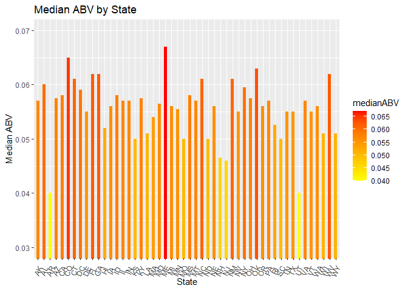

```r
## The two plots below present the states alphabetically.
beerclean %>% group_by(abbr) %>% summarise(medianABV= median(ABV))%>% ggplot(aes(abbr,medianABV, fill=medianABV))+geom_bar(stat="identity", width=.5)+ coord_cartesian(ylim=c(.03,.07)) + scale_fill_gradient(low = "yellow", high= "red")+ labs(title="Median ABV by State", x="State", y="Median ABV") + theme(axis.text.x = element_text(angle=65, vjust=.3))
```

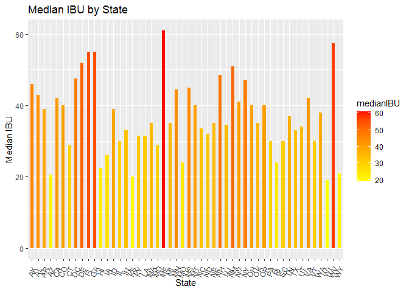

```r
beerclean %>% group_by(abbr) %>% summarise(medianIBU= median(IBU)) %>% ggplot(aes(abbr,medianIBU, fill=medianIBU))+geom_bar(stat="identity", width=.5) + scale_fill_gradient(low = "yellow", high= "red")+ labs(title="Median IBU by State", x="State", y="Median IBU") + theme(axis.text.x = element_text(angle=65, vjust=.3))
```

The code above plots the median ABV and IBU by state alphabetically. The view of the y axis was shifted from 0.0 to 0.03 to provide an easier way to see the differences between states. The color scheme was chosen to be consistent with all graphs.

## Which state has the most alcoholic and most bitter beer?

Louisville, KY has the most alcoholic beer. Astoria, OR has the most bitter beer.

```r
beerclean[grep(max(beerclean$ABV),beerclean$ABV),] %>% select(City, abbr, Name.y, Name.x, ABV)
```

```
##          City abbr                    Name.y         Name.x   ABV
## 40 Louisville   KY Against the Grain Brewery London Balling 0.125
```

```r
beerclean[grep(max(beerclean$IBU),beerclean$IBU),] %>% select(City, abbr, Name.y, Name.x, IBU)
```

```
##       City abbr                  Name.y                    Name.x IBU
## 89 Astoria   OR Astoria Brewing Company Bitter Bitch Imperial IPA 138
```

The code above finds the row of the highest ABV/IBU and then selects pertinent columns for a clean display.

## What does the ABV distribution look like in the United States?

The distribution of ABV shows a normal distribution with a right skew.

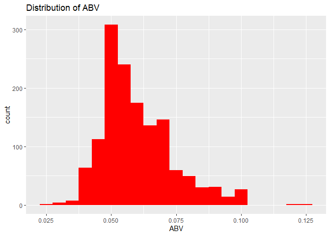

```r
beerclean %>% ggplot(aes(ABV)) + geom_histogram(fill ='red', binwidth = .005) + labs(title="Distribution of ABV")
```

```r
summarise(beerclean, max=max(ABV), min=min(ABV), mean = mean(ABV), median = median(ABV), sd=sd(ABV))
```

```
##     max   min       mean median         sd
## 1 0.125 0.027 0.05991388  0.057 0.01357633
```

The code above plots a histogram of ABV with a specific binwidth. A dataframe is also printed to show the max, min, mean, median and standard deviation.

## Is there a relationship between ABV and IBU?

There appears to be a positive linear relationship between Bitterness and Alcohol Content. As ABV increases, IBU increases.

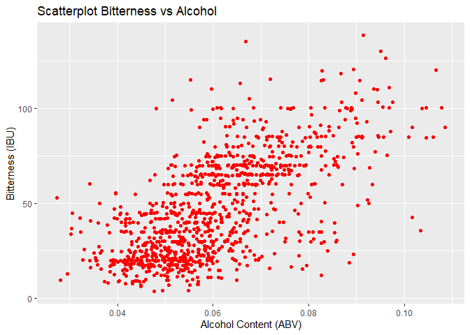

```r
IPA <- beerclean %>% filter(grepl("IPA",Style))
ALE <- beerclean %>% filter(grepl("Ale", Style))
LITE <-beerclean %>% filter(grepl("Pilsner", Style) | grepl("Lager", Style))
IPAC <- IPA %>% mutate(Beerclass = "IPA")
ALEC <- ALE %>% mutate(Beerclass = "ALE")
LITEC <- LITE %>% mutate(Beerclass = "Pilsner/Lager")
beertrain <- rbind(IPAC,ALEC,LITEC)
beertrain %>% ggplot(aes(ABV, IBU)) + geom_jitter(color='red', width=.01) + labs(title="Scatterplot Bitterness vs Alcohol", x="Alcohol Content (ABV)", y="Bitterness (IBU)")
```

The code above performs the initial categorization of styles for our KNN model, but plots all points in a uniform color. Jitter was chosen over point because it gave a better visual of the observations.

## Can we create a model to identify a beer as an IPA?

We were able to create a model to identfy an IPA with 74% accuracy. The sensitivity of the model is 76% and the specificity is 88%.

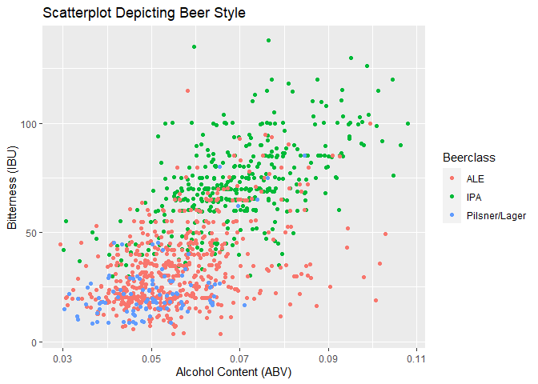

```r
beertrain %>% ggplot(aes(ABV, IBU, color=Beerclass)) + geom_jitter(width=.01) + labs(title="Scatterplot Depicting Beer Style", x="Alcohol Content (ABV)", y="Bitterness (IBU)")
```

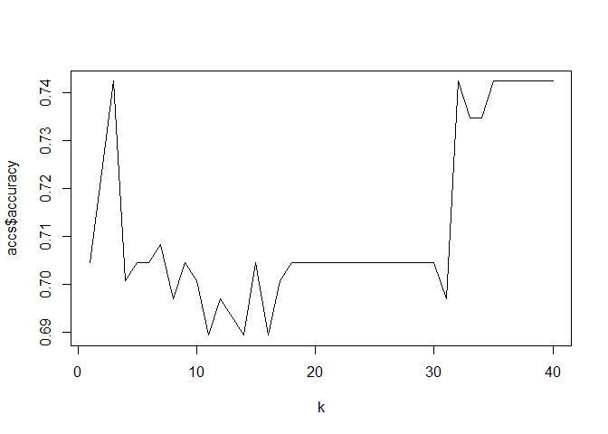

```r
#KNN train
set.seed(6)
splitPerc = .75
trainIndices = sample(1:dim(beertrain)[1],round(splitPerc * dim(beertrain)[1]))
train = beertrain[trainIndices,]
test = beertrain[-trainIndices,]
#finding most accurate K value
accs = data.frame(accuracy = numeric(40), k = numeric(40))
for(i in 1:40)
{
  classifications = knn(train[,c(3,4)],test[,c(3,4)],train$Beerclass, prob = TRUE, k = i)
  table(test$Beerclass,classifications)
  CM = confusionMatrix(table(test$Beerclass,classifications))
  accs$accuracy[i] = CM$overall[1]
  accs$k[i] = i
}
p = plot(accs$k,accs$accuracy, type = "l", xlab = "k")
```

```r
#knn
classifications = knn(train[,c(3,4)], test[,c(3,4)], train$Beerclass, prob = TRUE, k = 3)
table(classifications,test$Beerclass)
```

```
##
## classifications ALE IPA Pilsner/Lager
##   ALE           112  24            15
##   IPA            16  75             3
##   Pilsner/Lager  11   0             8
```

```r
confusionMatrix(table(classifications,test$Beerclass))
```

```
## Confusion Matrix and Statistics
##
##
## classifications ALE IPA Pilsner/Lager
##   ALE           112  24            15
##   IPA            16  75             3
##   Pilsner/Lager  11   0             8
##
## Overall Statistics
##
##                Accuracy : 0.7386
##                  95% CI : (0.6812, 0.7906)
##     No Information Rate : 0.5265
##     P-Value [Acc > NIR] : 1.249e-12
##
##                   Kappa : 0.5318
##
##  Mcnemar's Test P-Value : 0.1567
##
## Statistics by Class:
##
##                      Class: ALE Class: IPA Class: Pilsner/Lager
## Sensitivity              0.8058     0.7576              0.30769
## Specificity              0.6880     0.8848              0.95378
## Pos Pred Value           0.7417     0.7979              0.42105
## Neg Pred Value           0.7611     0.8588              0.92653
## Prevalence               0.5265     0.3750              0.09848
## Detection Rate           0.4242     0.2841              0.03030
## Detection Prevalence     0.5720     0.3561              0.07197
## Balanced Accuracy        0.7469     0.8212              0.63074
```

The code above replots the data set showing the the categories of style( IPA, Ale, Pilsner/Lager). The code then separates a training and test set, finds the most accurate K value, performs the kNN and prints the confusion matrix.

## What markets are good test areas for a new IPA?

In looking at the per captia consumption of beer by state, we found the top 10 states. These states would be a good test market for a new IPA. The graphic and table below show these states.

```r
#Source for per capita consumption: Kaplan, Jacob. Apparent Per Capita Alcohol Consumption: National, State, and Regional Trends 1977-2018. Ann Arbor, MI: Inter-university Consortium for Political and Social Research [distributor], 2020-06-29. https://doi.org/10.3886/E105583V4
beerrate <- read.csv(curl("https://raw.githubusercontent.com/tricleve/6306_CaseStudy1/master/apparent_per_capita_alcohol_consumption_1977_2018.csv"))
#filter to look at 2018
BR <- beerrate %>% filter(year == 2018)
#Select State, year and beer
BRR <- BR %>% select(state, year, number_of_beers)
#Column Rename
BRR <-BRR %>% rename(State = state, "Beers_per_person_2018" = "number_of_beers")
#pull state data for mapping
state.abb
```

```
##  [1] "AL" "AK" "AZ" "AR" "CA" "CO" "CT" "DE" "FL" "GA" "HI" "ID" "IL" "IN" "IA"
## [16] "KS" "KY" "LA" "ME" "MD" "MA" "MI" "MN" "MS" "MO" "MT" "NE" "NV" "NH" "NJ"
## [31] "NM" "NY" "NC" "ND" "OH" "OK" "OR" "PA" "RI" "SC" "SD" "TN" "TX" "UT" "VT"
## [46] "VA" "WA" "WV" "WI" "WY"
```

```r
state.name
```

```
##  [1] "Alabama"        "Alaska"         "Arizona"        "Arkansas"
##  [5] "California"     "Colorado"       "Connecticut"    "Delaware"
##  [9] "Florida"        "Georgia"        "Hawaii"         "Idaho"
## [13] "Illinois"       "Indiana"        "Iowa"           "Kansas"
## [17] "Kentucky"       "Louisiana"      "Maine"          "Maryland"
## [21] "Massachusetts"  "Michigan"       "Minnesota"      "Mississippi"
## [25] "Missouri"       "Montana"        "Nebraska"       "Nevada"
## [29] "New Hampshire"  "New Jersey"     "New Mexico"     "New York"
## [33] "North Carolina" "North Dakota"   "Ohio"           "Oklahoma"
## [37] "Oregon"         "Pennsylvania"   "Rhode Island"   "South Carolina"
## [41] "South Dakota"   "Tennessee"      "Texas"          "Utah"
## [45] "Vermont"        "Virginia"       "Washington"     "West Virginia"
## [49] "Wisconsin"      "Wyoming"
```

```r
df <- data.frame(state.abb,state.name)
df <- df %>% rename(State = state.name)
#merging state data
df2 <- regex_left_join(df,BRR, by = "State",ignore_case = TRUE)
df3 <- df2[-c(49,5),]
df4 <- df3[,-c(3,4)]
df4 <- df4 %>% rename(state = state.abb, State_Name = State.x)
df4 <- df4[order(-df4$Beers_per_person_2018),]
df5 <- df4[-c(11:50),]
#Top 10 states for per capita beer consumption
df5
```

```
##    state    State_Name Beers_per_person_2018
## 30    NH New Hampshire              424.2963
## 27    MT       Montana              379.2593
## 46    VT       Vermont              362.6667
## 35    ND  North Dakota              355.5556
## 42    SD  South Dakota              324.7407
## 29    NV        Nevada              320.0000
## 20    ME         Maine              317.6296
## 39    PA  Pennsylvania              305.7778
## 51    WI     Wisconsin              305.7778
## 12    HI        Hawaii              303.4074
```

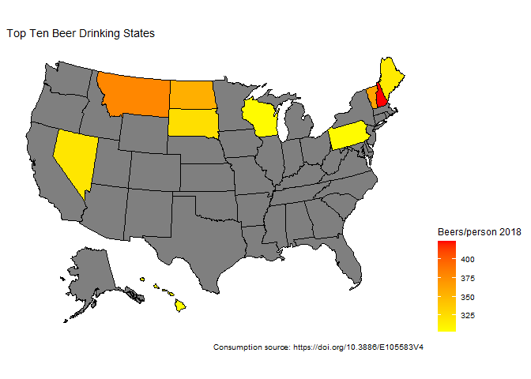

```r
#Plots
plot_usmap(data=df5, values="Beers_per_person_2018", color = "black") + labs(title = "Top Ten Beer Drinking States", legend.position = "center", caption = "Consumption source: https://doi.org/10.3886/E105583V4") + theme(legend.position = "right") + scale_fill_gradient(name = "Beers/person 2018", low = "yellow", high= "red")
```

This code grabs per capita consumption by state for 2018, merges it with state data and prints the top 10 states using plot_usmap. The top 10 states is printed out with the consumption information as well.